# M04-Reflection Essay-Advanced Data Visualization

Author

Isabelle Garza

Published

March 2, 2026

# 1 Summarize what you learned from the presentation by **Thomas Lin Pedersen** on “ggplot2 workshop: Part 2 in Step 1

The workshop by Thomas Lin Pedersen was transformative. The core insight was to treat plots not as monolithic final products, but as composable objects built from reusable parts. This philosophy, rooted in the grammar of graphics, demystifies complexity. By consciously separating data, aesthetics, geoms, and guides, even the most intricate visualizations become manageable.

This understanding unlocked the power of the `ggplot2` ecosystem. Extensions like `gganimate` no longer felt like magic, but a logical extension of the grammar, adding a time dimension to the plot. Similarly, `patchwork` provided a grammatical way to compose multiple plots into a single, coherent narrative. The key takeaway was that true power lies in composition and understanding the underlying structure, not in tweaking settings until a chart looks “good enough.

# 2 In Step 2, a short video on “**ggplot2 Scales and Transformations - Data Communication / Data Visualization | Video (13:36)**” was introduced. (1) Summarize it and (2) discuss how it fits with the grammar of graphics you learned in Step 1.

Building on this foundation, a video on “ggplot2 Scales and Transformations” clarified that scales are the critical translators between your data and your audience. A plot’s ability to communicate honestly and effectively hinges on scale choices.

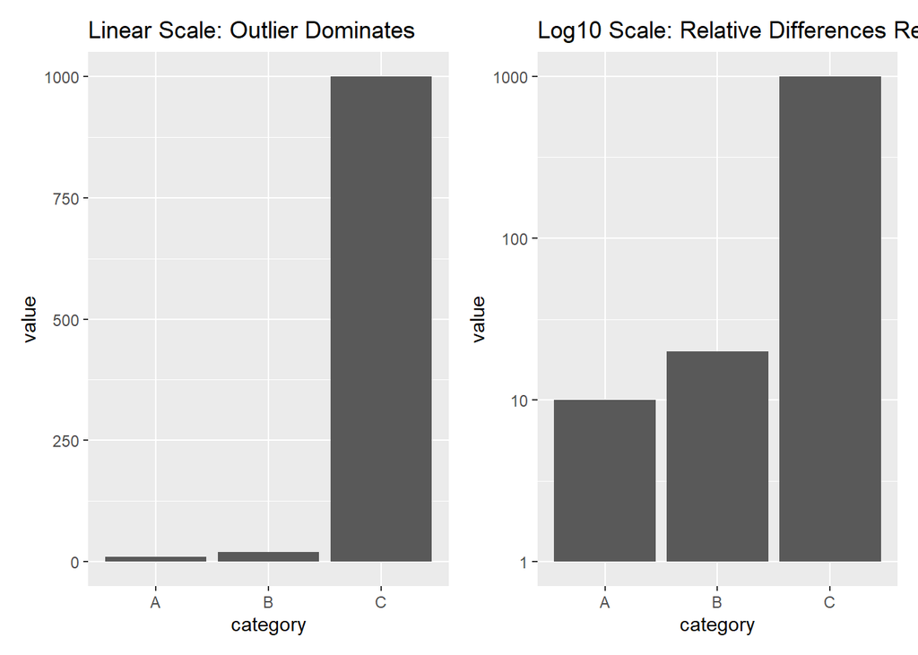

```r
# Scales example

library(ggplot2)

# Data with an extreme outlier
df <- data.frame(
  category = c("A", "B", "C"),
  value = c(10, 20, 1000)
)

# Plot 1: Linear scale
p1 <- ggplot(df, aes(x = category, y = value)) +
  geom_col() +
  labs(title = "Linear Scale: Outlier Dominates")

# Plot 2: Log10 scale
p2 <- ggplot(df, aes(x = category, y = value)) +
  geom_col() +
  scale_y_log10() +
  labs(title = "Log10 Scale: Relative Differences Revealed")

#Using patchwork to view them side-by-side
library(patchwork)
p1 + p2
```

# 3 In Step 3, **David Robinson’s video** demonstrates impromptu data visualization. List three new functions that were not taught previously but were deemed helpful for you in the future. Briefly explain what you can do with each of the functions

David Robinson’s approach to impromptu data visualization highlighted the importance of a tight, iterative workflow. Speed in exploration comes from a small set of high leverage functions that allow for quick inspection and reshaping.

Here are three functions that stood out as essential for my future workflow:

1. **`dplyr::count()`**: An incredibly fast way to summarize frequencies and get an immediate sense of distribution.
2. **`tidyr::separate()`**: This function is a lifesaver for cleaning messy, combined text fields, turning a single column into multiple usable variables for faceting and grouping.
3. **`forcats::fct_reorder()`**: This function reorders factor levels based on another numeric variable, ensuring that bar charts and legends automatically reflect the underlying pattern, making insights jump out.

These functions reduce friction, allowing for rapid cycles of computation, visualization, and questioning, which is the heart of effective exploratory analysis. See below a examples highlighting the use of these functions from my understanding:

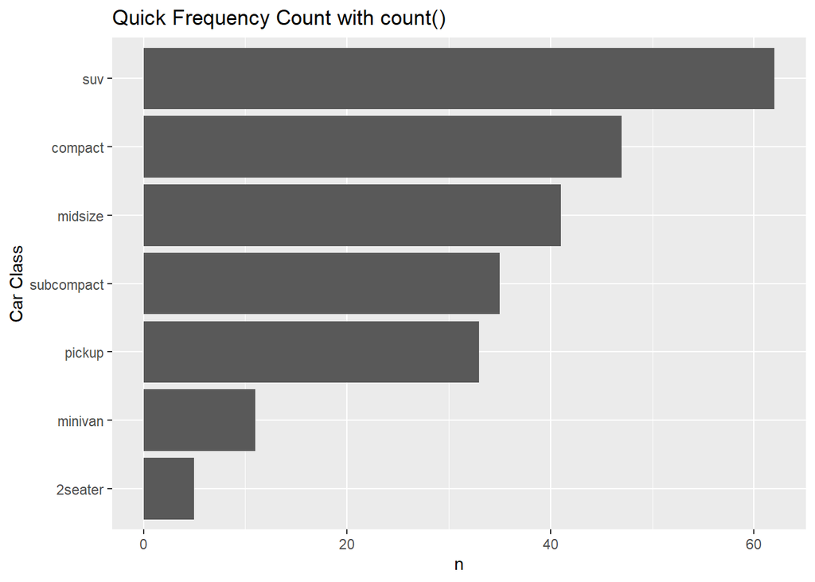

```r
library(dplyr)
library(ggplot2)

# Using the built-in mpg dataset
# Instead of grouping and summarizing, count() does it in one step
mpg %>%
  count(class) %>%
  ggplot(aes(x = reorder(class, n), y = n)) +
  geom_col() +
  coord_flip() +
  labs(title = "Quick Frequency Count with count()", x = "Car Class")
```

```r
library(tidyr)

messy_df <- data.frame(id = 1:3, info = c("Model_A_Red", "Model_B_Blue", "Model_C_Green"))

# Separate into meaningful columns using separate function
clean_df <- messy_df %>%
  separate(info, into = c("model", "color"), sep = "_")
print(clean_df)
```

```
  id model color
1  1 Model     A
2  2 Model     B
3  3 Model     C
```

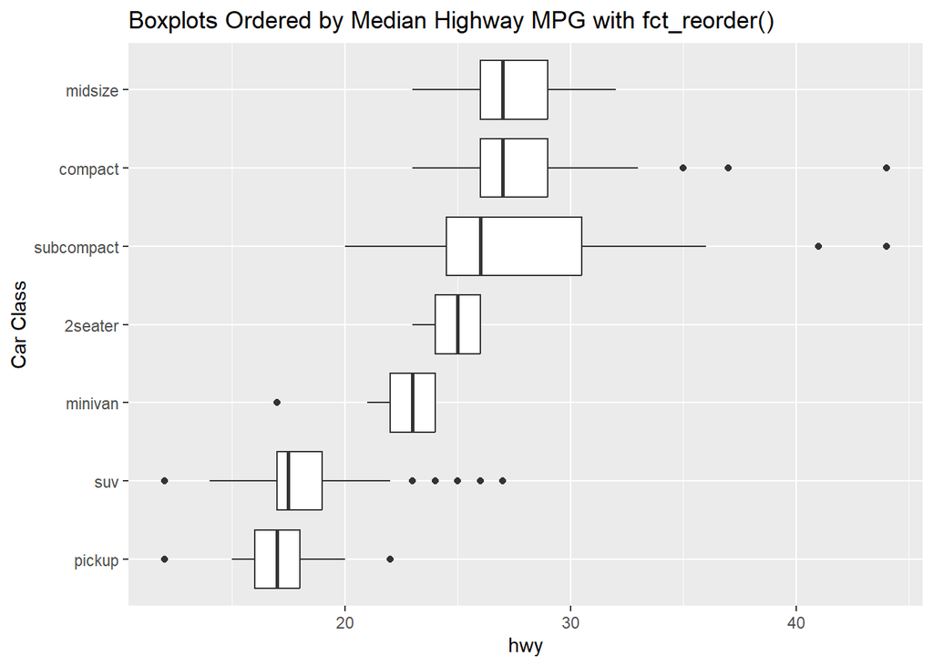

```r
library(forcats)

# Reorder the 'class' category by average 'hwy' mpg for a clearer plot
mpg %>%
  mutate(class = fct_reorder(class, hwy, .fun = median)) %>%
  ggplot(aes(x = class, y = hwy)) +
  geom_boxplot() +
  coord_flip() +
  labs(title = "Boxplots Ordered by Median Highway MPG with fct_reorder()", x = "Car Class")
```

# 4 What did you like about the **gt** and **gtExtra** packages demonstrated in Step 4? How do they complement data visualization using charts that we have spent so much time on so far? Under what circumstances would you prefer to use tables over charts in visualization data?

```r
library(tidyverse)
library(gt)
# gt example
mtcars %>%
  group_by(cyl) %>%
  summarize(mpg_data = list(mpg), .groups = "drop") %>%
  gt() %>%
  tab_header(title = "Fuel Efficiency Distribution by Cylinder")
```

Fuel Efficiency Distribution by Cylinder

| cyl | mpg_data |
| --- | --- |
| 4 | 22.8, 24.4, 22.8, 32.4, 30.4, 33.9, 21.5, 27.3, 26.0, 30.4, 21.4 |
| 6 | 21.0, 21.0, 21.4, 18.1, 19.2, 17.8, 19.7 |
| 8 | 18.7, 14.3, 16.4, 17.3, 15.2, 10.4, 10.4, 14.7, 15.5, 15.2, 13.3, 19.2, 15.8, 15.0 |

> While charts excel at showing patterns, tables are superior for presenting exact values, supporting multi-level headers, or serving as a reference appendix. The combination of `gt`‘s formatting rigor and `gtExtras`’ ability to embed mini visuals (like sparklines) means a single table can communicate trend, spread, and precise figures simultaneously. I would now choose a table when precision is paramount and a chart when the primary goal is to reveal a relationship or pattern. They are partners, not rivals, in clear communication.

# 5 Pick three tips and tricks you learned from Data Visualization guru **Cédric Schere** in Step 5 and explain why you liked them.

Cédric Scherer’s talk shifted my focus from what to add to a plot to what to remove or constrain. His tips are about intentional, deliberate design that serves the message.

- **Use perceptually uniform palettes**: Adopting palettes like Viridis ensures that changes in color value are perceived as equal changes in data value, without introducing false visual emphasis.
- **Refine typography and space**: Mastering theme details, consistent font sizes, adjusted margins, and lighter gridlines, creates a clear visual hierarchy and guides the viewer’s eye without distraction.
- **Practice intentional nnnotation**: Annotate sparingly. Highlight the two or three key data points or trends, and let the rest of the data speak for itself in silence.

These principles resonated because they are not one time fixes but repeatable methods. They push me to edit ruthlessly, ensuring that every visual element on the canvas has a purpose in telling the core story.

# 6 In Step 6, you will find my advanced visualization notebook. Run the codes one by one and digest as much as you can. What are you most impressed with about the visualization approach or tools demonstrated in the codebook?

- I was impressed by the fact that ggplot package is not an island but the foundation of a vast, unified toolkit capable of handling any storytelling scenario, from simple plots to complex, interactive, and geospatial narratives.
- The same grammatical principles that build a bar chart can be extended to build an interactive bubble chart with `plotly`, an animated time-series with `gganimate`, or a geospatial map with `sf` and `rnaturalearth`.
- This ecosystem empowers you to move fluidly between different types of visualizations, choosing the most effective format for your data and your message, all within a single, coherent framework.

```r
# Conceptual flow of the codebook


# Interactive Exploration with plotly
# plotly::ggplotly(static_plot)

# Animation with gganimate
# library(gganimate)
# static_plot + transition_time(year) + labs(title = 'Year: {frame_time}')

# Geospatial Mapping with rnaturalearth
# library(rnaturalearth)
# world <- ne_countries(scale = "medium", returnclass = "sf")
# ggplot(world) + geom_sf(aes(fill = gdp_md_est))
```

# 7 What seems to be the challenge, if any, for you when you try to master data visualization skills? How may you be able to overcome the challenge?

## 7.1 Challenges identified.

> Mastering data visualization has been the greatest challenge to me because of balancing creativity and clarity not to forget so many ggplot2 details that govern scales, themes and layering. At some point once I leave behind simple charts, I can freeze in the process of selecting encodings or struggling to debug strange extensions.

## 7.2 Plan to overcome these challenges.

> I can overcome that by executing every new change in loops: keep it very simple, add a new change and re-read the message again. The advanced codebook will be executed line by line, which will enable me to learn individually what each line does before it is being customized. A very short checklist depending on the module objectives that will be part of the correlations, five-variable layers, animation and maps will be maintained. I will also recreate one of the plots in the videos every week and compare my performance to the original. That habit ought to initiate disorientation into familiarity and create consistent assurance.